# Final Project

Oleh Bohoslavets

12/15/2019

#### Seasonal time series: Unemployment Rate

#### URL: https://fred.stlouisfed.org/graph/?g=lSBW

#### Source: U.S. Bureau of Labor Statistics Release: Employment Situation

#### Units: Percent, Not Seasonally Adjusted

#### Frequency: Monthly

#### Time: 1948-01-01 to 2019-10-01

#### The unemployment rate represents the number of unemployed as a percentage of the labor force. Labor force data are restricted to people 16 years of age and older, who currently reside in 1 of the 50 states or the District of Columbia, who do not reside in institutions (e.g., penal and mental facilities, homes for the aged), and who are not on active duty in the Armed Forces.

#### This rate is also defined as the U-3 measure of labor underutilization.

#### The series comes from the ‘Current Population Survey (Household Survey)’

#### The source code is: LNU04000000

#### Citation:

#### U.S. Bureau of Labor Statistics, Unemployment Rate [UNRATENSA], retrieved from FRED, Federal Reserve Bank of St. Louis; https://fred.stlouisfed.org/series/UNRATENSA, December 5, 2019.

```r
Unemployment <- read.csv("Unemployment Rate.csv")
names(Unemployment)
```

```
## [1] "DATE"      "UNRATENSA"
```

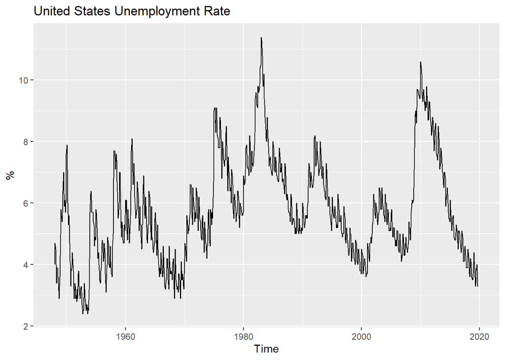

```r
U <- ts(Unemployment$UNRATENSA, start = 1948, frequency = 12)
autoplot(U) + ggtitle("United States Unemployment Rate") + ylab("%")
```

#### The plot of Unemployement rate displays many spikes, in recent years the unemployement had been going down. In my opinion there was a lot variation in the past that is not related to the current state of economy, therefore we will only consider the data starting from year 2010.

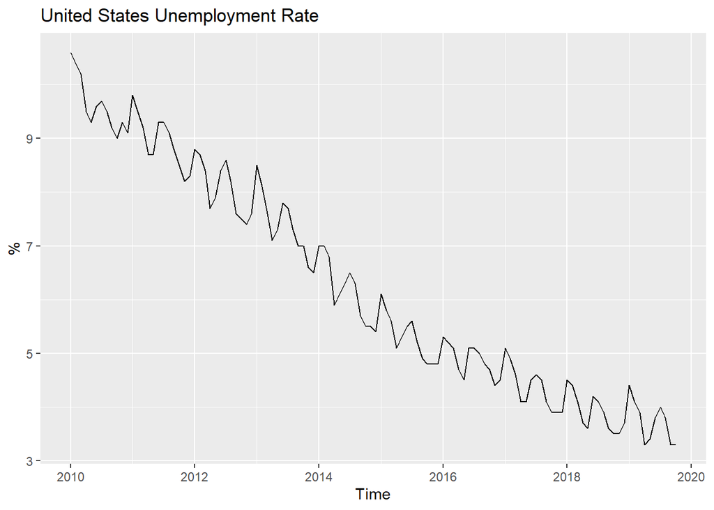

```r
U = window(U, start = 2010)
autoplot(U) + ggtitle("United States Unemployment Rate") + ylab("%")
```

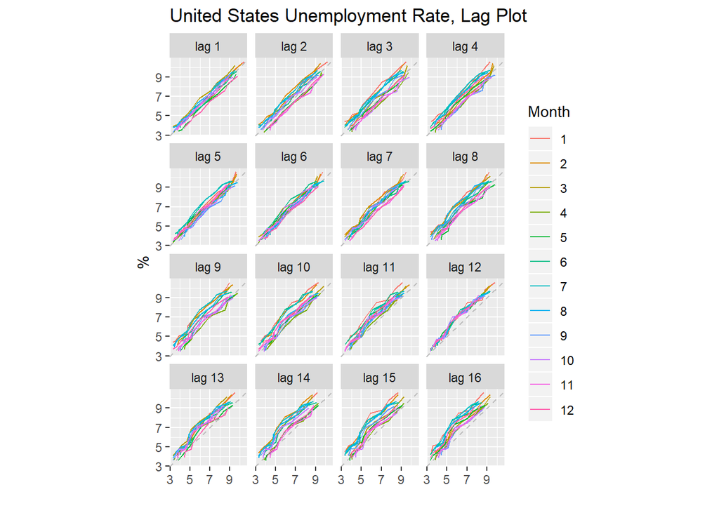

```r
gglagplot(U) + ggtitle("United States Unemployment Rate, Lag Plot") + ylab("%")
```

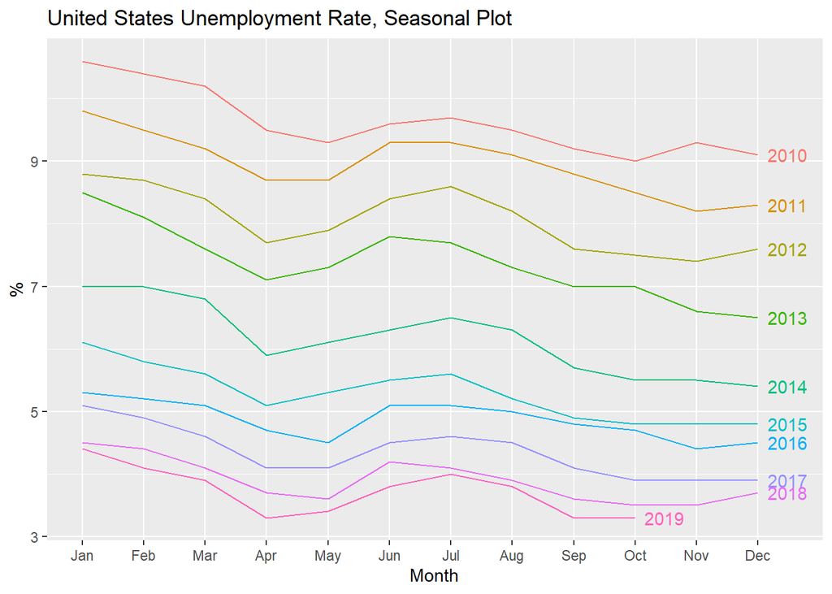

```r
ggseasonplot(U, year.labels = T) + ggtitle("United States Unemployment Rate, Seasonal Plot") + ylab("%")
```

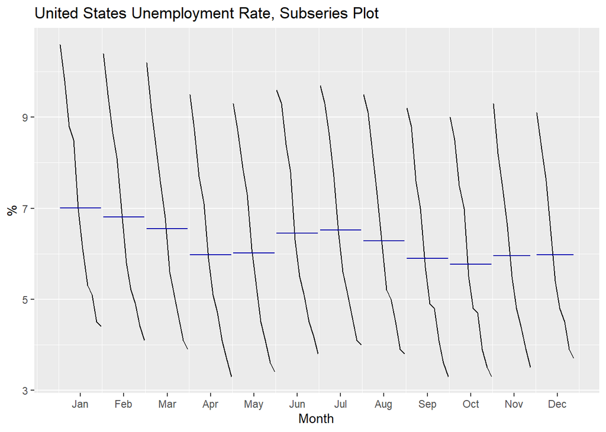

```r
ggsubseriesplot(U) + ggtitle("United States Unemployment Rate, Subseries Plot") + ylab("%")
```

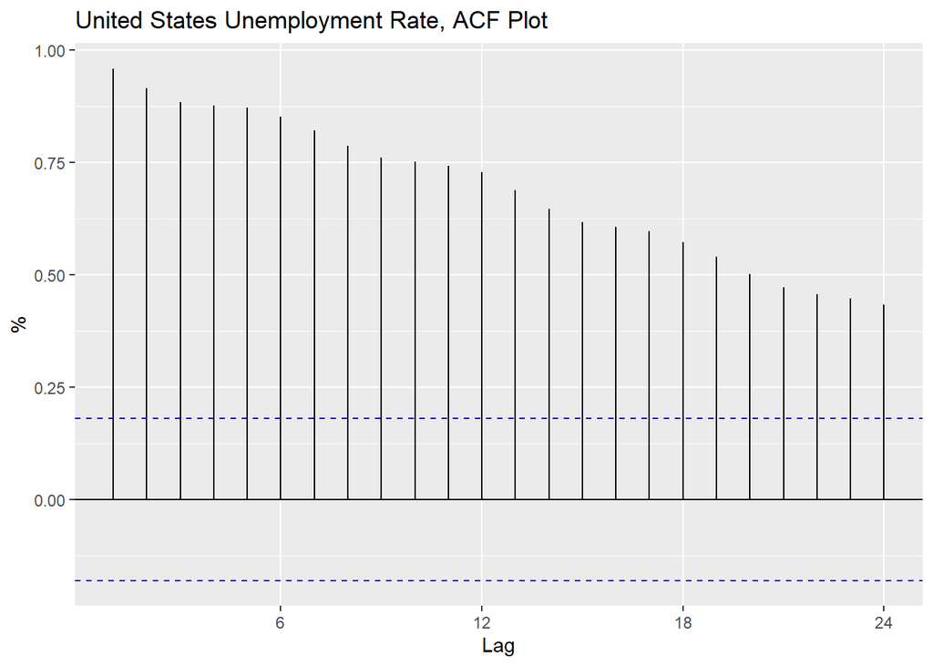

```r
ggAcf(U) + ggtitle("United States Unemployment Rate, ACF Plot") + ylab("%")
```

#### Let’s see if any transformation is appropriate.

```r
lambda = BoxCox.lambda(U)
lambda
```

```
## [1] 0.6606927
```

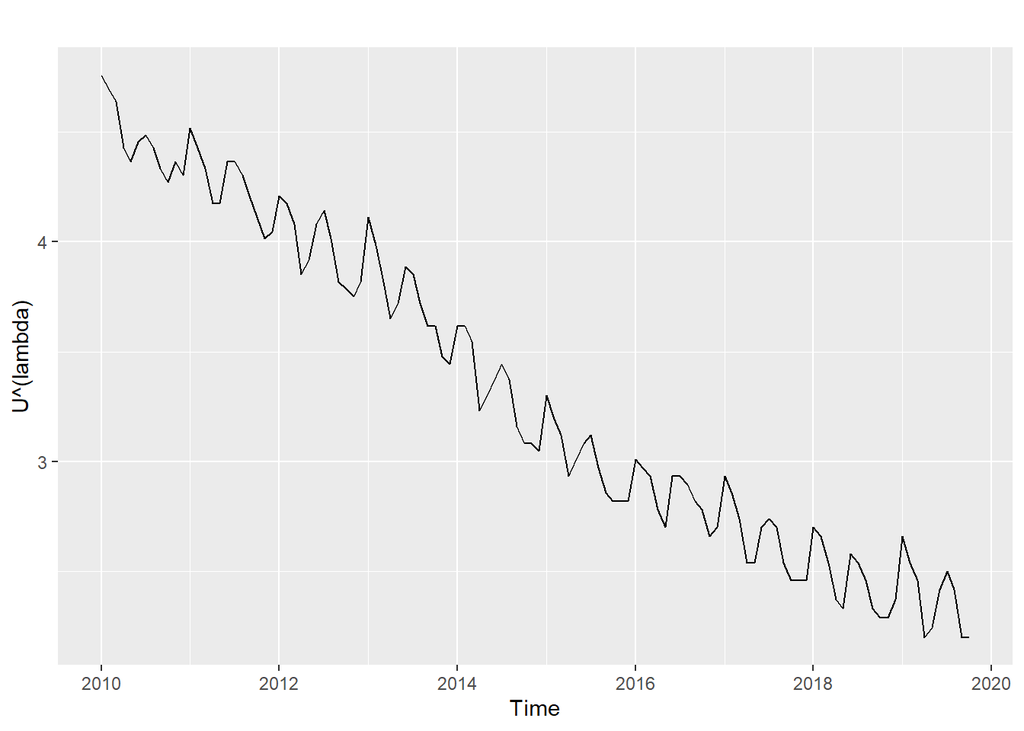

```r
autoplot(U^(lambda))
```

#### Box-Cox transformation suggests lambda that is close to 0.5 which is a square root therefore we will consider the sqrt transformation on the data when making models.

#### Let’s use the basic forecasting methods to make forecasts as a baseline for our future models. Mean method is not appropriate because we have a downward trend.

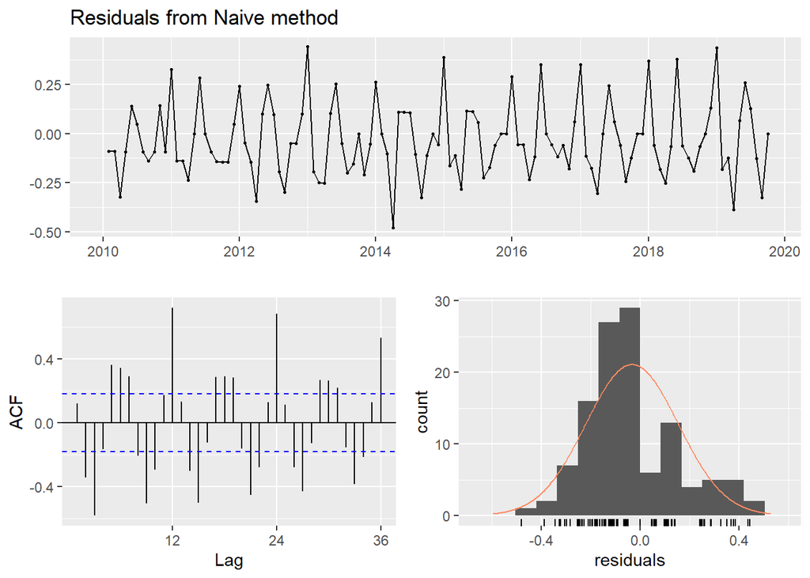

```
##
##  Ljung-Box test
##
## data:  Residuals from Naive method
## Q* = 426.99, df = 24, p-value < 2.2e-16
##
## Model df: 0.   Total lags used: 24
```

```r
U_naive = naive(U, lambda = lambda, h = 24)
U_snaive = snaive(U, lambda = lambda, h = 24)
U_rwf = rwf(U, drift = T, lambda = lambda, h = 24)


checkresiduals(U_naive)
```

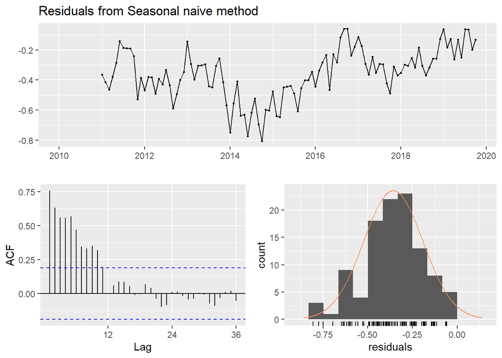

```
##
##  Ljung-Box test
##
## data:  Residuals from Seasonal naive method
## Q* = 302.12, df = 24, p-value < 2.2e-16
##
## Model df: 0.   Total lags used: 24
```

```r
checkresiduals(U_snaive)
```

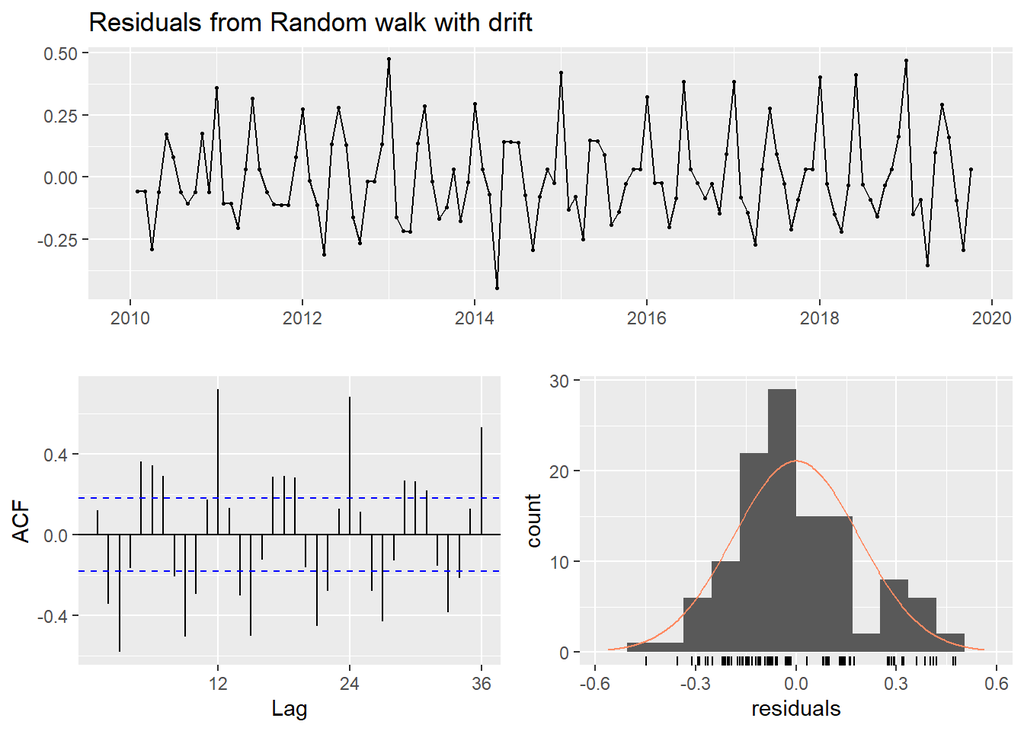

```
##
##  Ljung-Box test
##
## data:  Residuals from Random walk with drift
## Q* = 426.99, df = 23, p-value < 2.2e-16
##
## Model df: 1.   Total lags used: 24
```

```r
checkresiduals(U_rwf)
```

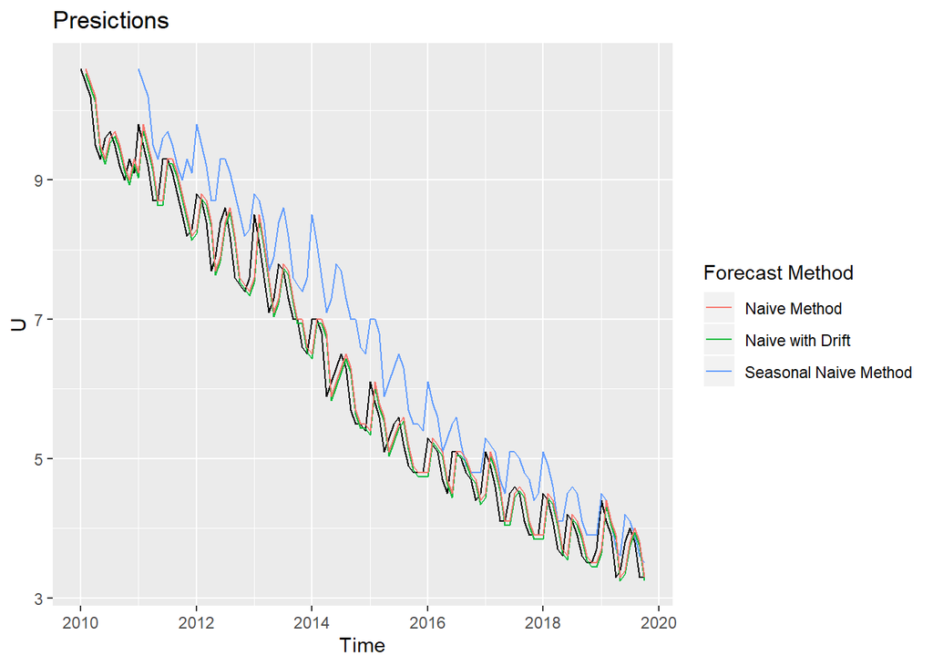

```r
autoplot(U) + ggtitle("Presictions")+
  autolayer(fitted(U_snaive), series = "Seasonal Naive Method") +
  autolayer(fitted(U_rwf), series = "Naive with Drift") +
  autolayer(fitted(U_naive), series = "Naive Method") +
  guides(color = guide_legend(title = "Forecast Method"))
```

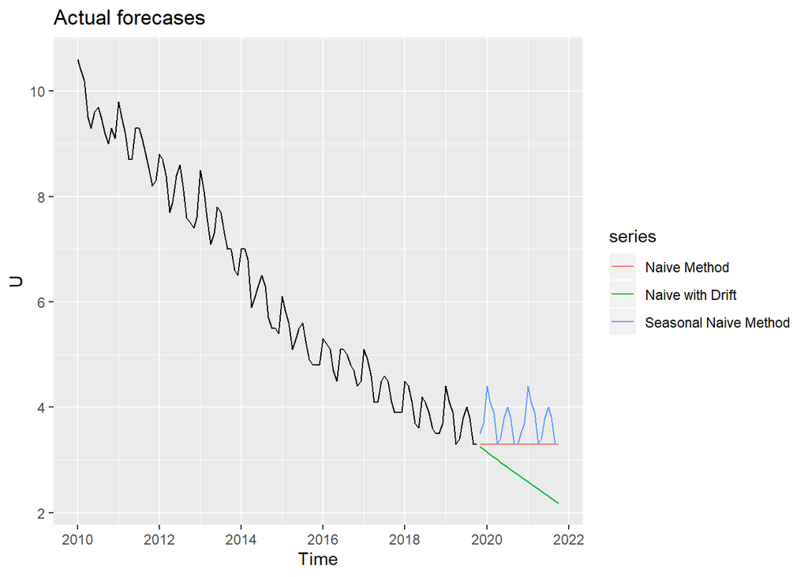

```r
autoplot(U) + ggtitle("Actual forecases") +
  autolayer(U_snaive$mean, series = "Seasonal Naive Method") +
  autolayer(U_rwf$mean, series = "Naive with Drift") +
  autolayer(U_naive$mean, series = "Naive Method")
```

#### Naive and Naive with Drift methods residuals are centered around 0 and roughly normally distributed, significant autocorrelation structure. Seasonal Naive method residuals are below 0 which means we are consistently overestimating the unemployment rate.

#### Let’s check the cross validation procedure to see how methods perform on the step forecasts

```r
e_n_1 = tsCV(U, rwf, h = 1)
sqrt(mean(e_n_1^2, na.rm = T))
```

```
## [1] 0.3485011
```

```r
e_sn_1 = tsCV(U, snaive, h = 1)
sqrt(mean(e_sn_1^2, na.rm = T))
```

```
## [1] 0.7936177
```

```r
e_rwf_1 = tsCV(U, rwf, drift = T, h = 1)
sqrt(mean(e_rwf_1^2, na.rm = T))
```

```
## [1] 0.3511577
```

```r
e_n_12 = tsCV(U, rwf, h = 12)
sqrt(mean(e_n_12^2, na.rm = T))
```

```
## [1] 0.6242125
```

```r
e_sn_12 = tsCV(U, snaive, h = 12)
sqrt(mean(e_sn_12^2, na.rm = T))
```

```
## [1] 0.7486361
```

```r
e_rwf_12 = tsCV(U, rwf , drift = T, h = 12)
sqrt(mean(e_rwf_12^2, na.rm = T))
```

```
## [1] 0.6518303
```

#### Naive method outperforms other methods on 1 step forecast and on 12 step forecast.

#### Let’s now do the training/test split and see how these methods predict new data

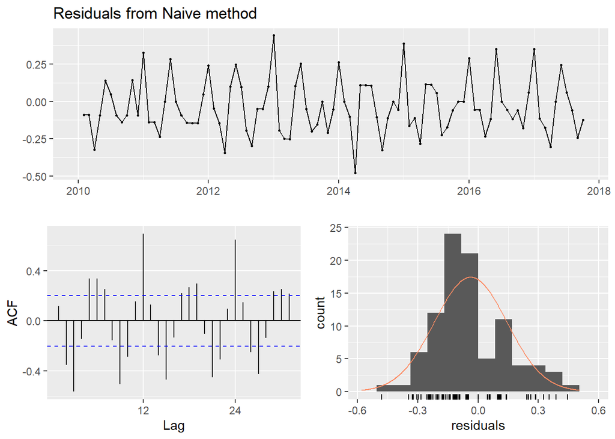

```
##
##  Ljung-Box test
##
## data:  Residuals from Naive method
## Q* = 230.89, df = 19, p-value < 2.2e-16
##
## Model df: 0.   Total lags used: 19
```

```r
U_train = head(U, length(U)-24)
U_test = tail(U, 24)

U_naive = naive(U_train, lambda = lambda, h = 24)
U_snaive = snaive(U_train, lambda = lambda, h = 24)
U_rwf = rwf(U_train, drift = T, lambda = lambda, h = 24)

checkresiduals(U_naive)
```

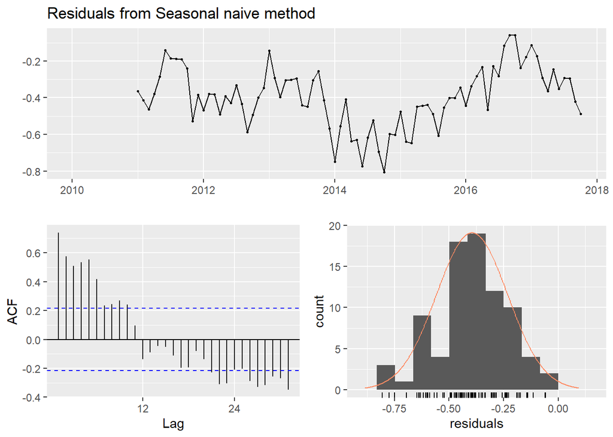

```
##
##  Ljung-Box test
##
## data:  Residuals from Seasonal naive method
## Q* = 202.67, df = 19, p-value < 2.2e-16
##
## Model df: 0.   Total lags used: 19
```

```r
checkresiduals(U_snaive)
```

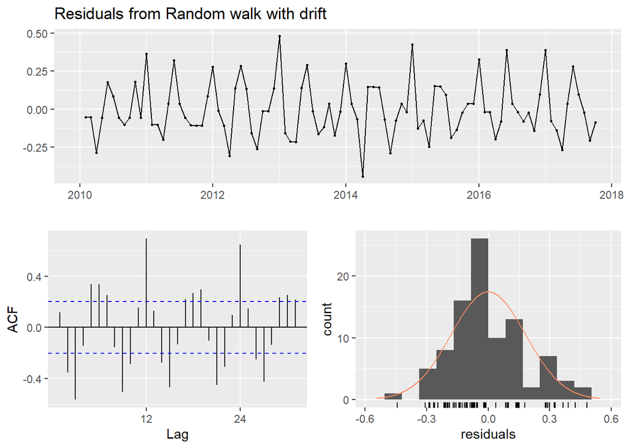

```
##
##  Ljung-Box test
##
## data:  Residuals from Random walk with drift
## Q* = 230.89, df = 18, p-value < 2.2e-16
##
## Model df: 1.   Total lags used: 19
```

```r
checkresiduals(U_rwf)
```

```r
accuracy(U_naive, U_test)
```

```
##                       ME      RMSE       MAE       MPE     MAPE      MASE
## Training set -0.07204301 0.3524111 0.2849462 -1.222510 4.332936 0.3762575
## Test set     -0.07083333 0.3541422 0.2875000 -2.687979 7.716114 0.3796296
##                  ACF1 Theil's U
## Training set 0.119355        NA
## Test set     0.490405  1.089651
```

```r
accuracy(U_snaive, U_test)
```

```
##                      ME      RMSE       MAE       MPE     MAPE      MASE
## Training set -0.7573171 0.8209899 0.7573171 -12.12497 12.12497 1.0000000
## Test set     -0.6125000 0.6301455 0.6125000 -16.23500 16.23500 0.8087762
##                   ACF1 Theil's U
## Training set 0.7473704        NA
## Test set     0.4842637   1.88238
```

```r
accuracy(U_rwf, U_test)
```

```
##                         ME      RMSE       MAE        MPE     MAPE
## Training set -0.0005562742 0.3441590 0.2694727 -0.1268887  4.08846
## Test set      0.6394081300 0.7365399 0.6394081 16.4838770 16.48388
##                   MASE      ACF1 Theil's U
## Training set 0.3558255 0.1183828        NA
## Test set     0.8443070 0.5302839  2.201499
```

#### Residual diagnostics display simmilar problems as before. Accuracy measures show that Naive method performs best on new data.

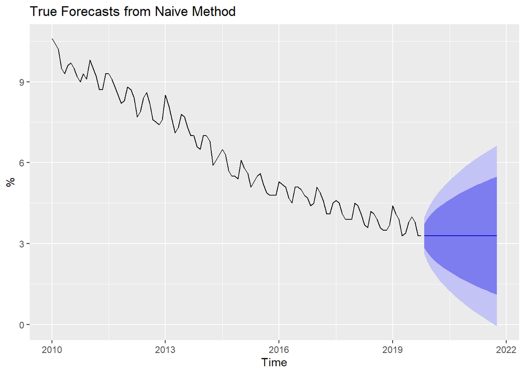

```r
U_naive = naive(U, h = 24)
autoplot(U_naive)+ ggtitle("True Forecasts from Naive Method") +ylab("%")
```

```r
U_naive$mean
```

```
##      Jan Feb Mar Apr May Jun Jul Aug Sep Oct Nov Dec
## 2019                                         3.3 3.3
## 2020 3.3 3.3 3.3 3.3 3.3 3.3 3.3 3.3 3.3 3.3 3.3 3.3
## 2021 3.3 3.3 3.3 3.3 3.3 3.3 3.3 3.3 3.3 3.3
```

#### Let’s consider several linear models and see which ones satisfy our assumptions. We will start with linear models. Scince our data highly seasonal we will include the season and trend terms.

```r
U_lm = tslm(U ~ trend + season)
summary(U_lm)
```

```
##
## Call:
## tslm(formula = U ~ trend + season)
##
## Residuals:
##      Min       1Q   Median       3Q      Max
## -0.72458 -0.20745  0.02697  0.22229  0.72881
##
## Coefficients:
##              Estimate Std. Error t value Pr(>|t|)
## (Intercept) 10.268047   0.129739  79.144  < 2e-16 ***
## trend       -0.059237   0.001006 -58.885  < 2e-16 ***
## season2     -0.140763   0.165961  -0.848  0.39827
## season3     -0.341526   0.165970  -2.058  0.04209 *
## season4     -0.852288   0.165986  -5.135 1.31e-06 ***
## season5     -0.753051   0.166007  -4.536 1.53e-05 ***
## season6     -0.263814   0.166034  -1.589  0.11509
## season7     -0.134577   0.166068  -0.810  0.41956
## season8     -0.315340   0.166107  -1.898  0.06039 .
## season9     -0.636102   0.166153  -3.828  0.00022 ***
## season10    -0.706865   0.166205  -4.253 4.59e-05 ***
## season11    -0.817496   0.170553  -4.793 5.43e-06 ***
## season12    -0.736036   0.170580  -4.315 3.62e-05 ***
## ---
## Signif. codes:  0 '***' 0.001 '**' 0.01 '*' 0.05 '.' 0.1 ' ' 1
##
## Residual standard error: 0.3711 on 105 degrees of freedom
## Multiple R-squared:  0.9716, Adjusted R-squared:  0.9684
## F-statistic: 299.3 on 12 and 105 DF,  p-value: < 2.2e-16
```

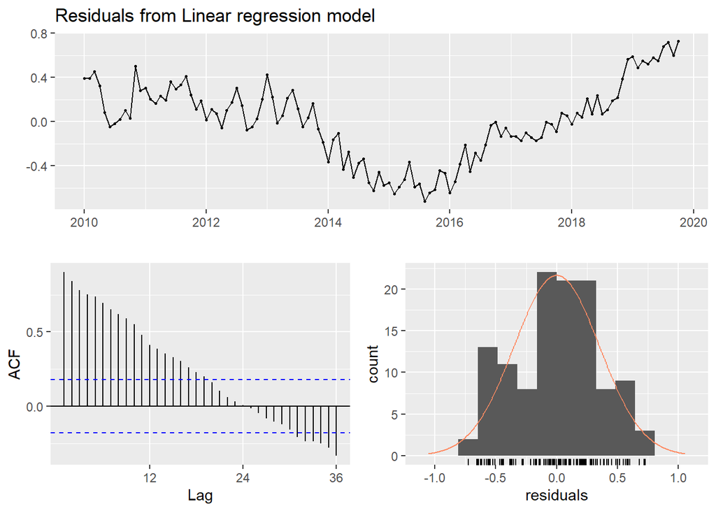

```
##
##  Breusch-Godfrey test for serial correlation of order up to 24
##
## data:  Residuals from Linear regression model
## LM test = 104.73, df = 24, p-value = 4.643e-12
```

```r
checkresiduals(U_lm)
```

```r
U_lm_t = tslm(U  ~ trend + season, lambda = lambda)
summary(U_lm_t)
```

```
##
## Call:
## tslm(formula = U ~ trend + season, lambda = lambda)
##
## Residuals:
##      Min       1Q   Median       3Q      Max
## -0.34774 -0.08985  0.01380  0.10443  0.33599
##
## Coefficients:
##               Estimate Std. Error t value Pr(>|t|)
## (Intercept)  5.6563723  0.0579875  97.545  < 2e-16 ***
## trend       -0.0317851  0.0004496 -70.693  < 2e-16 ***
## season2     -0.0734733  0.0741770  -0.991   0.3242
## season3     -0.1798835  0.0741810  -2.425   0.0170 *
## season4     -0.4581735  0.0741879  -6.176 1.26e-08 ***
## season5     -0.4049469  0.0741974  -5.458 3.24e-07 ***
## season6     -0.1355445  0.0742097  -1.827   0.0706 .
## season7     -0.0657835  0.0742246  -0.886   0.3775
## season8     -0.1624025  0.0742423  -2.187   0.0309 *
## season9     -0.3418286  0.0742628  -4.603 1.17e-05 ***
## season10    -0.3808569  0.0742859  -5.127 1.35e-06 ***
## season11    -0.4308302  0.0762294  -5.652 1.37e-07 ***
## season12    -0.3839011  0.0762413  -5.035 1.99e-06 ***
## ---
## Signif. codes:  0 '***' 0.001 '**' 0.01 '*' 0.05 '.' 0.1 ' ' 1
##
## Residual standard error: 0.1659 on 105 degrees of freedom
## Multiple R-squared:  0.9941, Adjusted R-squared:  0.9934
## F-statistic:  1477 on 12 and 105 DF,  p-value: < 2.2e-16
```

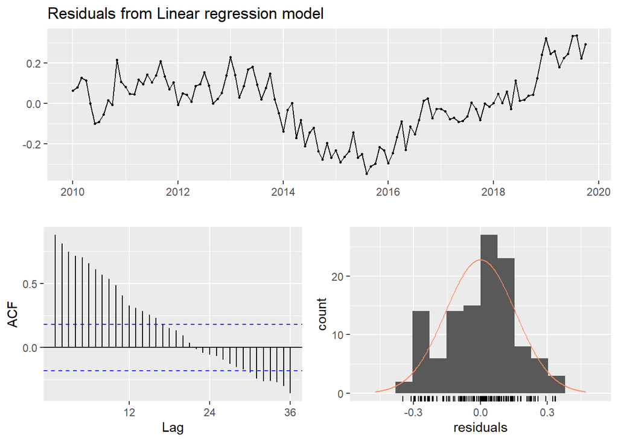

```
##
##  Breusch-Godfrey test for serial correlation of order up to 24
##
## data:  Residuals from Linear regression model
## LM test = 100.76, df = 24, p-value = 2.227e-11
```

```r
checkresiduals(U_lm_t)
```

#### It is clear that linear model is not appropriate because the trend parameter is estimated using drift method and our data has unsteady trend. We need to dynamically change the trend.

#### We will use automatic seasonal decomposition methods X-11 or SEATS to decompose the series. We will not use classical decomposition because we want to allow for seasonal component to change. We will also consider additive and multiplicative decompositions.

```r
U_X11_add = seas(U, transform.function = "none", x11 = "")
summary(U_X11_add)
```

```
##
## Call:
## seas(x = U, transform.function = "none", x11 = "")
##
## Coefficients:
##                    Estimate Std. Error z value Pr(>|z|)
## Constant           0.008147   0.002016   4.042 5.31e-05 ***
## LS2010.Nov         0.457723   0.116701   3.922 8.77e-05 ***
## AR-Nonseasonal-01  0.025153   0.185053   0.136   0.8919
## AR-Nonseasonal-02 -0.173848   0.092476  -1.880   0.0601 .
## AR-Nonseasonal-03 -0.246045   0.096636  -2.546   0.0109 *
## MA-Nonseasonal-01  0.345226   0.185894   1.857   0.0633 .
## MA-Seasonal-12     0.999956   0.093489  10.696  < 2e-16 ***
## ---
## Signif. codes:  0 '***' 0.001 '**' 0.01 '*' 0.05 '.' 0.1 ' ' 1
##
## X11 adj.  ARIMA: (3 1 1)(0 1 1)  Obs.: 118  Transform: none
## AICc: -99.09, BIC: -79.35  QS (no seasonality in final):    0
## Box-Ljung (no autocorr.): 25.12   Shapiro (normality): 0.9913
```

```r
U_X13_add = seas(U, transform.function = "none")
summary(U_X13_add)
```

```
##
## Call:
## seas(x = U, transform.function = "none")
##
## Coefficients:
##                    Estimate Std. Error z value Pr(>|z|)
## Constant           0.008147   0.002016   4.042 5.31e-05 ***
## LS2010.Nov         0.457723   0.116701   3.922 8.77e-05 ***
## AR-Nonseasonal-01  0.025153   0.185053   0.136   0.8919
## AR-Nonseasonal-02 -0.173848   0.092476  -1.880   0.0601 .
## AR-Nonseasonal-03 -0.246045   0.096636  -2.546   0.0109 *
## MA-Nonseasonal-01  0.345226   0.185894   1.857   0.0633 .
## MA-Seasonal-12     0.999956   0.093489  10.696  < 2e-16 ***
## ---
## Signif. codes:  0 '***' 0.001 '**' 0.01 '*' 0.05 '.' 0.1 ' ' 1
##
## SEATS adj.  ARIMA: (3 1 1)(0 1 1)  Obs.: 118  Transform: none
## AICc: -99.09, BIC: -79.35  QS (no seasonality in final):    0
## Box-Ljung (no autocorr.): 25.12   Shapiro (normality): 0.9913
```

```r
U_X11_mult = seas(U, x11 = "")
summary(U_X11_mult)
```

```
##
## Call:
## seas(x = U, x11 = "")
##
## Coefficients:
##                    Estimate Std. Error z value Pr(>|z|)
## Constant           0.008147   0.002016   4.042 5.31e-05 ***
## LS2010.Nov         0.457723   0.116701   3.922 8.77e-05 ***
## AR-Nonseasonal-01  0.025153   0.185053   0.136   0.8919
## AR-Nonseasonal-02 -0.173848   0.092476  -1.880   0.0601 .
## AR-Nonseasonal-03 -0.246045   0.096636  -2.546   0.0109 *
## MA-Nonseasonal-01  0.345226   0.185894   1.857   0.0633 .
## MA-Seasonal-12     0.999956   0.093489  10.696  < 2e-16 ***
## ---
## Signif. codes:  0 '***' 0.001 '**' 0.01 '*' 0.05 '.' 0.1 ' ' 1
##
## X11 adj.  ARIMA: (3 1 1)(0 1 1)  Obs.: 118  Transform: none
## AICc: -99.09, BIC: -79.35  QS (no seasonality in final):    0
## Box-Ljung (no autocorr.): 25.12   Shapiro (normality): 0.9913
```

```r
U_X13_mult = seas(U)
summary(U_X13_mult)
```

```
##
## Call:
## seas(x = U)
##
## Coefficients:
##                    Estimate Std. Error z value Pr(>|z|)
## Constant           0.008147   0.002016   4.042 5.31e-05 ***
## LS2010.Nov         0.457723   0.116701   3.922 8.77e-05 ***
## AR-Nonseasonal-01  0.025153   0.185053   0.136   0.8919
## AR-Nonseasonal-02 -0.173848   0.092476  -1.880   0.0601 .
## AR-Nonseasonal-03 -0.246045   0.096636  -2.546   0.0109 *
## MA-Nonseasonal-01  0.345226   0.185894   1.857   0.0633 .
## MA-Seasonal-12     0.999956   0.093489  10.696  < 2e-16 ***
## ---
## Signif. codes:  0 '***' 0.001 '**' 0.01 '*' 0.05 '.' 0.1 ' ' 1
##
## SEATS adj.  ARIMA: (3 1 1)(0 1 1)  Obs.: 118  Transform: none
## AICc: -99.09, BIC: -79.35  QS (no seasonality in final):    0
## Box-Ljung (no autocorr.): 25.12   Shapiro (normality): 0.9913
```

```r
U_stl1 = stl(U, t.window = 13, s.window = "periodic")
summary(U_stl1)
```

```
##  Call:
##  stl(x = U, s.window = "periodic", t.window = 13)
##
##  Time.series components:
##     seasonal              trend             remainder
##  Min.   :-0.3288683   Min.   : 3.628426   Min.   :-0.23316752
##  1st Qu.:-0.2741757   1st Qu.: 4.401787   1st Qu.:-0.07538500
##  Median : 0.0665932   Median : 5.725589   Median :-0.01132255
##  Mean   : 0.0043955   Mean   : 6.271440   Mean   :-0.00210692
##  3rd Qu.: 0.2558291   3rd Qu.: 8.115894   3rd Qu.: 0.05841023
##  Max.   : 0.5436692   Max.   :10.052489   Max.   : 0.26945952
##  IQR:
##      STL.seasonal STL.trend STL.remainder data
##      0.5300       3.7141    0.1338        3.7000
##    %  14.3        100.4       3.6         100.0
##
##  Weights: all == 1
##
##  Other components: List of 5
##  $ win  : Named num [1:3] 1181 13 13
##  $ deg  : Named int [1:3] 0 1 1
##  $ jump : Named num [1:3] 119 2 2
##  $ inner: int 2
##  $ outer: int 0
```

```r
U_stl2 = stl(U, t.window = 13, s.window = 13)
summary(U_stl2)
```

```
##  Call:
##  stl(x = U, s.window = 13, t.window = 13)
##
##  Time.series components:
##     seasonal              trend             remainder
##  Min.   :-0.3552495   Min.   : 3.585210   Min.   :-0.21492497
##  1st Qu.:-0.2637952   1st Qu.: 4.409845   1st Qu.:-0.06795915
##  Median : 0.0917322   Median : 5.729991   Median :-0.01397341
##  Mean   : 0.0047918   Mean   : 6.270946   Mean   :-0.00200872
##  3rd Qu.: 0.2604709   3rd Qu.: 8.103936   3rd Qu.: 0.05606967
##  Max.   : 0.5266485   Max.   :10.075801   Max.   : 0.28119249
##  IQR:
##      STL.seasonal STL.trend STL.remainder data
##      0.5243       3.6941    0.1240        3.7000
##    %  14.2         99.8       3.4         100.0
##
##  Weights: all == 1
##
##  Other components: List of 5
##  $ win  : Named num [1:3] 13 13 13
##  $ deg  : Named int [1:3] 0 1 1
##  $ jump : Named num [1:3] 2 2 2
##  $ inner: int 2
##  $ outer: int 0
```

```r
U_stl3 = stl(U, t.window = 13, s.window = 17)
summary(U_stl3)
```

```
##  Call:
##  stl(x = U, s.window = 17, t.window = 13)
##
##  Time.series components:
##     seasonal              trend             remainder
##  Min.   :-0.3435255   Min.   : 3.599365   Min.   :-0.22231330
##  1st Qu.:-0.2539813   1st Qu.: 4.405335   1st Qu.:-0.07084130
##  Median : 0.0824329   Median : 5.727684   Median :-0.01322238
##  Mean   : 0.0046313   Mean   : 6.271158   Mean   :-0.00206051
##  3rd Qu.: 0.2601780   3rd Qu.: 8.109817   3rd Qu.: 0.06063445
##  Max.   : 0.5305454   Max.   :10.070893   Max.   : 0.27477548
##  IQR:
##      STL.seasonal STL.trend STL.remainder data
##      0.5142       3.7045    0.1315        3.7000
##    %  13.9        100.1       3.6         100.0
##
##  Weights: all == 1
##
##  Other components: List of 5
##  $ win  : Named num [1:3] 17 13 13
##  $ deg  : Named int [1:3] 0 1 1
##  $ jump : Named num [1:3] 2 2 2
##  $ inner: int 2
##  $ outer: int 0
```

```r
checkresiduals(U_X11_add)
```

[output not shown]

```r
checkresiduals(U_X11_mult)
```

[output not shown]

```r
checkresiduals(U_X13_add)
```

[output not shown]

```r
checkresiduals(U_X13_mult)
```

[output not shown]

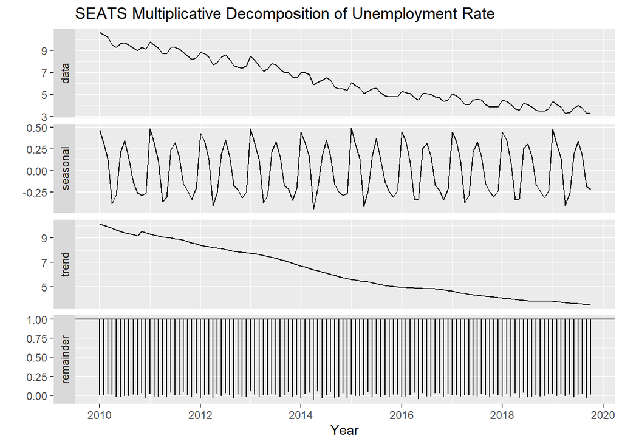

```r
autoplot(U_X13_mult) + ggtitle("SEATS Multiplicative Decomposition of Unemployment Rate") + xlab("Year")
```

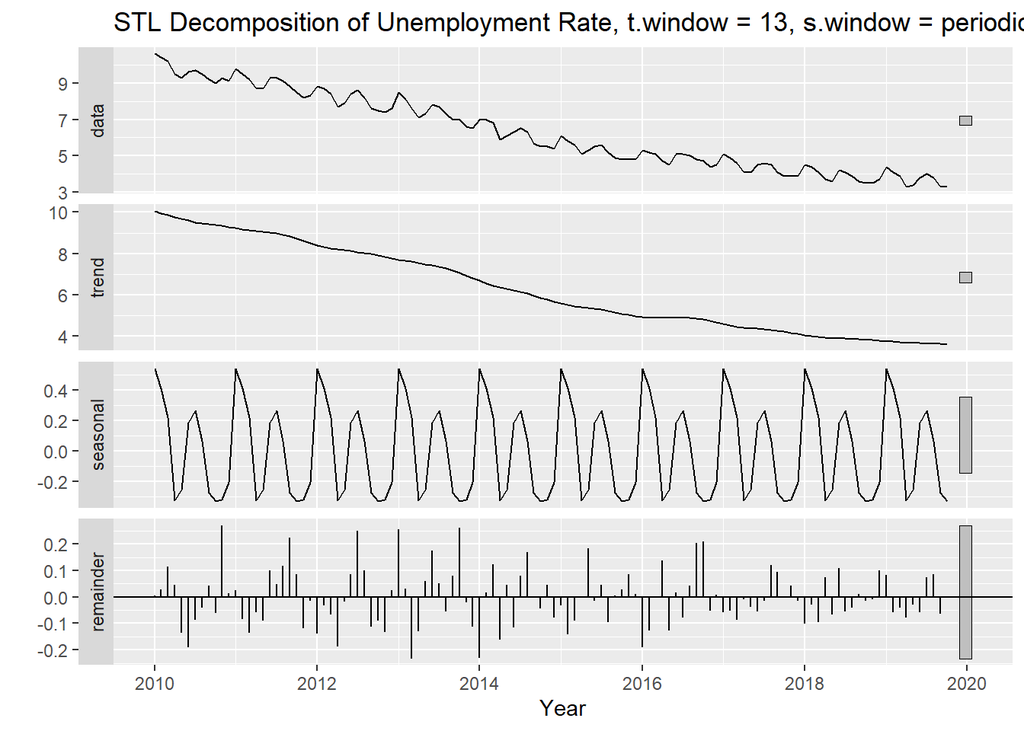

```r
autoplot(U_stl1) + ggtitle("STL Decomposition of Unemployment Rate, t.window = 13, s.window = periodic") + xlab("Year")
```

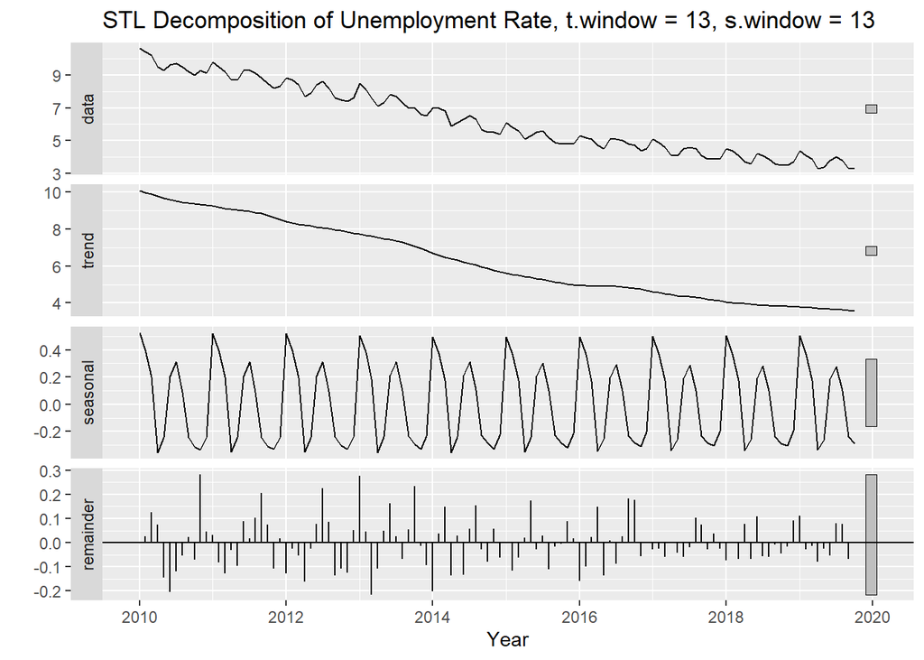

```r
autoplot(U_stl2) + ggtitle("STL Decomposition of Unemployment Rate, t.window = 13, s.window = 13") + xlab("Year")
```

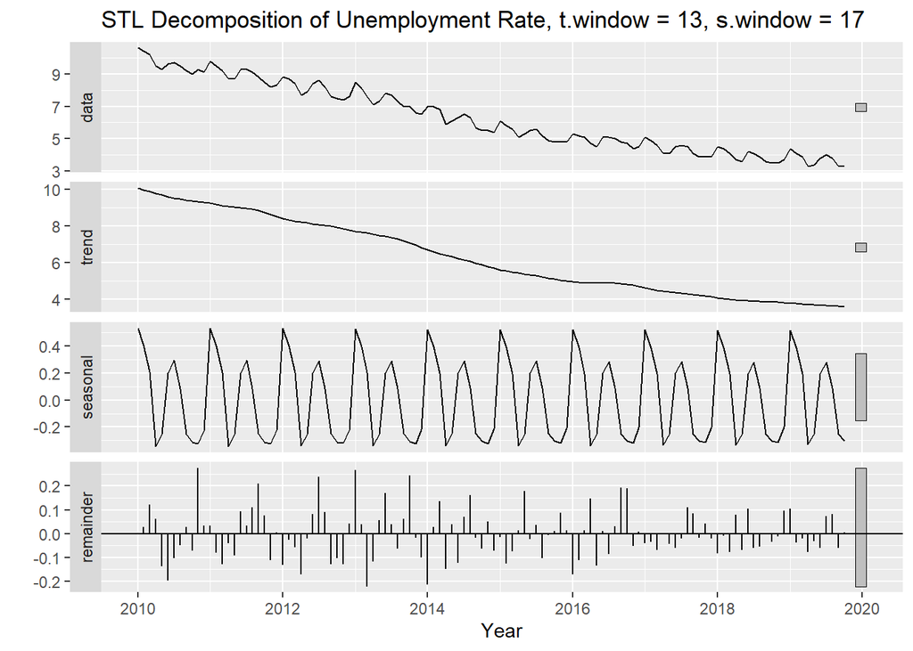

```r
autoplot(U_stl3) + ggtitle("STL Decomposition of Unemployment Rate, t.window = 13, s.window = 17") + xlab("Year")
```

#### Surprisingly the residuals from SEATS and X_11 are identical as well as for additive and multiplicative decomposition. STL Decomposition of Unemployment Rate with t.window = 13, s.window = “periodic” seems to be most appropriate, the seasonality is not changing too much with time and the trend is dynamically changing. This is a good visualization for us to better understand the trend and seasonal components of the data.

#### Let’s consider some of the exponential smoothing methods. There is no point in checking the Simple Exponential Smoothing and Holt’s Linear Trend Method because our data is highly seasonal. Now let’s evaluate the performance of the Holt-Winters Seasonal methods

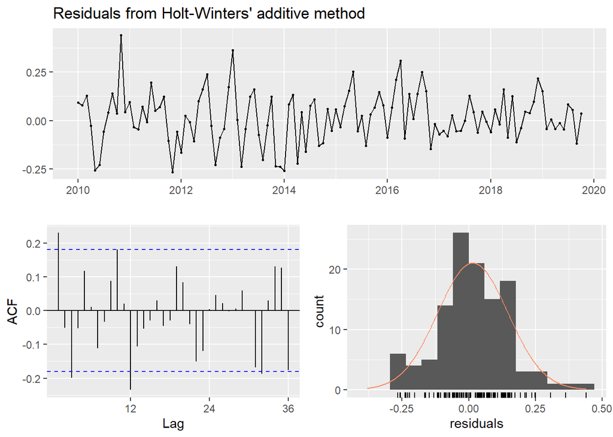

```
##
##  Ljung-Box test
##
## data:  Residuals from Holt-Winters' additive method
## Q* = 39.864, df = 8, p-value = 3.397e-06
##
## Model df: 16.   Total lags used: 24
```

```r
U_hw_add = hw(U, seasonal = "additive")
checkresiduals(U_hw_add)
```

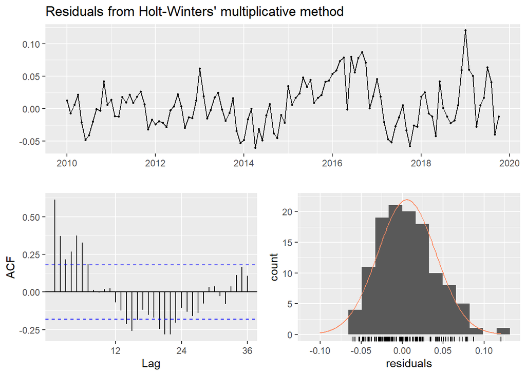

```
##
##  Ljung-Box test
##
## data:  Residuals from Holt-Winters' multiplicative method
## Q* = 184.39, df = 8, p-value < 2.2e-16
##
## Model df: 16.   Total lags used: 24
```

```r
U_hw_mult = hw(U, seasonal = "multiplicative")
checkresiduals(U_hw_mult)
```

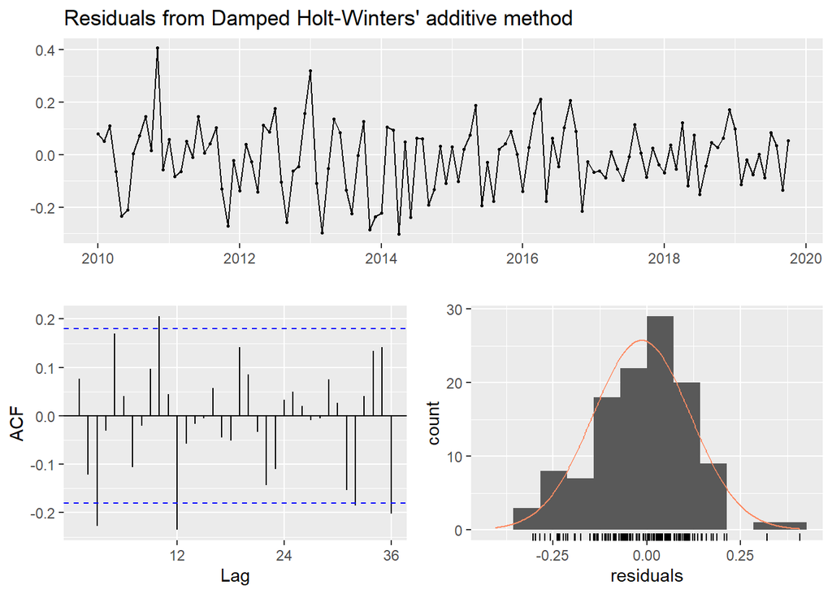

```
##
##  Ljung-Box test
##
## data:  Residuals from Damped Holt-Winters' additive method
## Q* = 39.371, df = 7, p-value = 1.661e-06
##
## Model df: 17.   Total lags used: 24
```

```r
U_hw_add_d = hw(U, seasonal = "additive", damped = TRUE)
checkresiduals(U_hw_add_d)
```

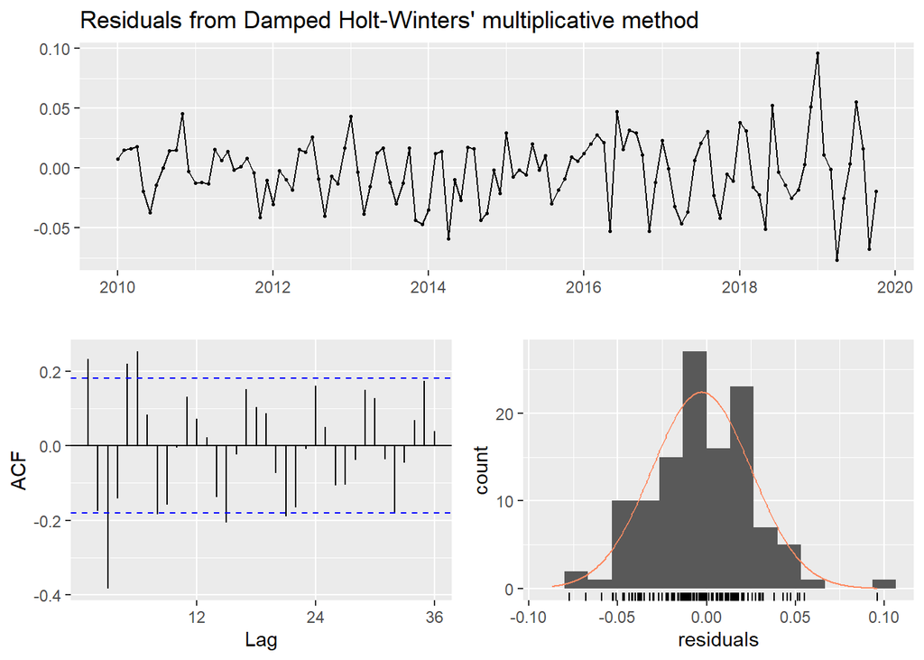

```
##
##  Ljung-Box test
##
## data:  Residuals from Damped Holt-Winters' multiplicative method
## Q* = 84.799, df = 7, p-value = 1.443e-15
##
## Model df: 17.   Total lags used: 24
```

```r
U_hw_mult_d = hw(U, seasonal = "multiplicative", damped = TRUE)
checkresiduals(U_hw_mult_d)
```

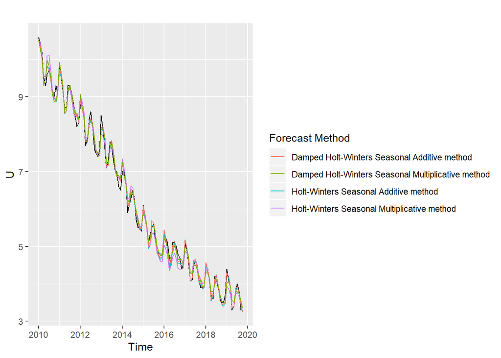

```r
autoplot(U) +
  autolayer(fitted(U_hw_add), series = "Holt-Winters Seasonal Additive method") +
  autolayer(fitted(U_hw_mult), series = "Holt-Winters Seasonal Multiplicative method") +
  autolayer(fitted(U_hw_add_d), series = "Damped Holt-Winters Seasonal Additive method") +
  autolayer(fitted(U_hw_mult_d), series = "Damped Holt-Winters Seasonal Multiplicative method") +
  guides(color = guide_legend(title = "Forecast Method"))
```

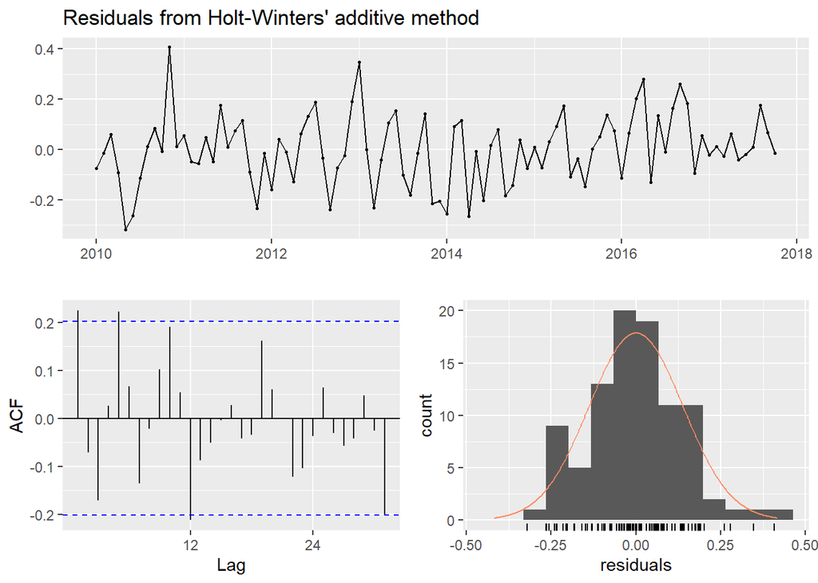

```
##
##  Ljung-Box test
##
## data:  Residuals from Holt-Winters' additive method
## Q* = 30.787, df = 3, p-value = 9.426e-07
##
## Model df: 16.   Total lags used: 19
```

```r
U_hw_add = hw(U_train, seasonal = "additive")
checkresiduals(U_hw_add)
```

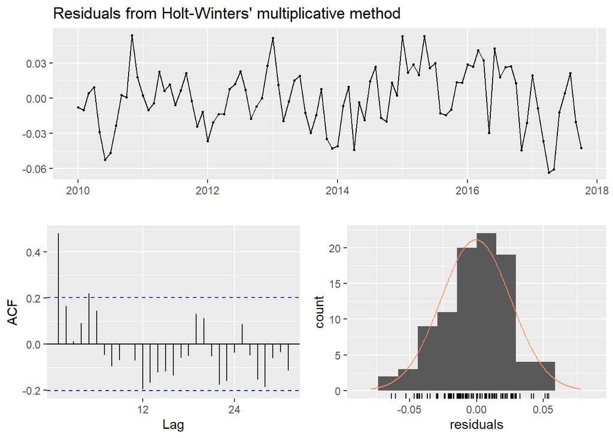

```
##
##  Ljung-Box test
##
## data:  Residuals from Holt-Winters' multiplicative method
## Q* = 50.956, df = 3, p-value = 4.998e-11
##
## Model df: 16.   Total lags used: 19
```

```r
U_hw_mult = hw(U_train, seasonal = "multiplicative")
checkresiduals(U_hw_mult)
```

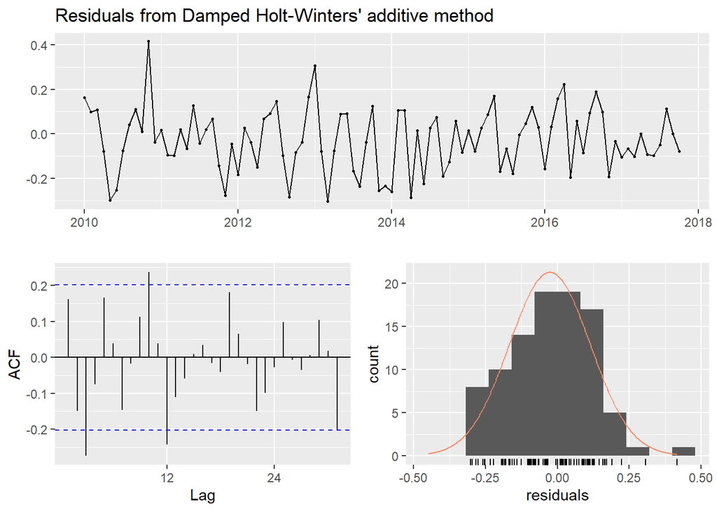

```
##
##  Ljung-Box test
##
## data:  Residuals from Damped Holt-Winters' additive method
## Q* = 38.675, df = 3, p-value = 2.034e-08
##
## Model df: 17.   Total lags used: 20
```

```r
U_hw_add_d = hw(U_train, seasonal = "additive", damped = TRUE)
checkresiduals(U_hw_add_d)
```

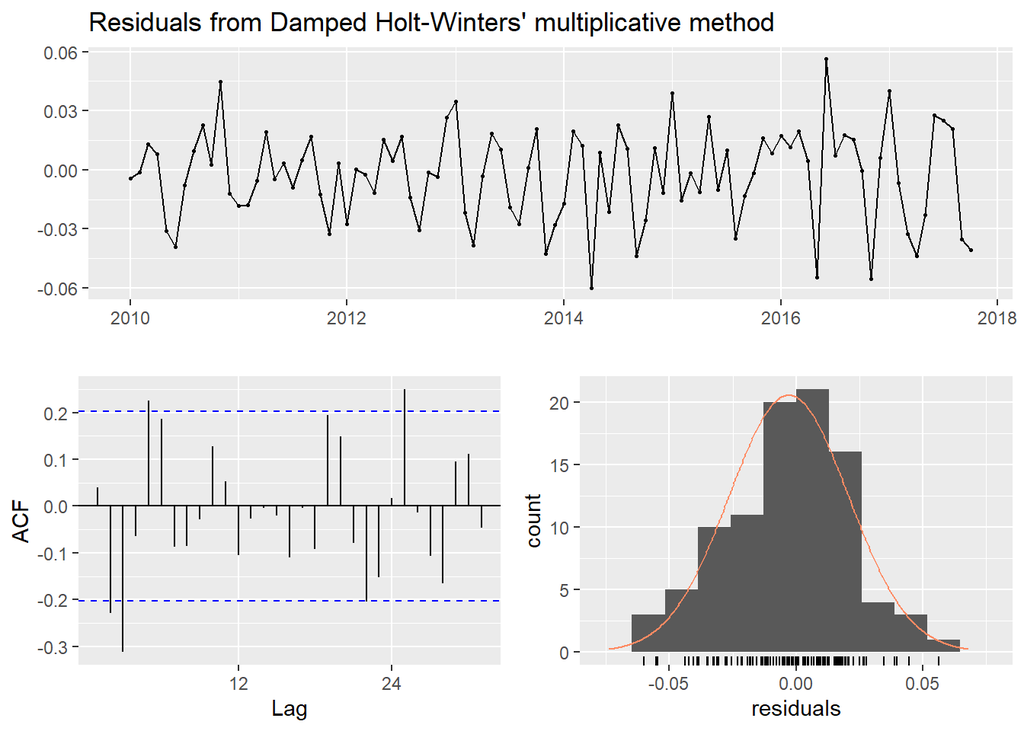

```
##
##  Ljung-Box test
##
## data:  Residuals from Damped Holt-Winters' multiplicative method
## Q* = 38.721, df = 3, p-value = 1.989e-08
##
## Model df: 17.   Total lags used: 20
```

```r
U_hw_mult_d = hw(U_train, seasonal = "multiplicative", damped = TRUE)
checkresiduals(U_hw_mult_d)
```